# HW 07: Data Importing and Wrangling 1

Ryan McAnulty

19 July 2020

#### Limpets

## Loading tidyverse and reading limpets.csv data

```r
library(tidyverse)
library(here)
```

The data is tidy.

## Defining limpets_data and forcing column types

```r
limpets_data <- read_csv(here("data", "limpets.csv"), col_types = "ncc")
```

## Setting levels for Site

```r
limpets_data$Site <- factor(limpets_data$Site, levels = c("PBL", "KNRM", "VBG", "WP", "PF", "DP", "SIO", "CTZ1", "CTZ2", "CNMM"), ordered = TRUE)
```

## Box plot of limpets_data Length (mm) vs. Site with Protected status colored

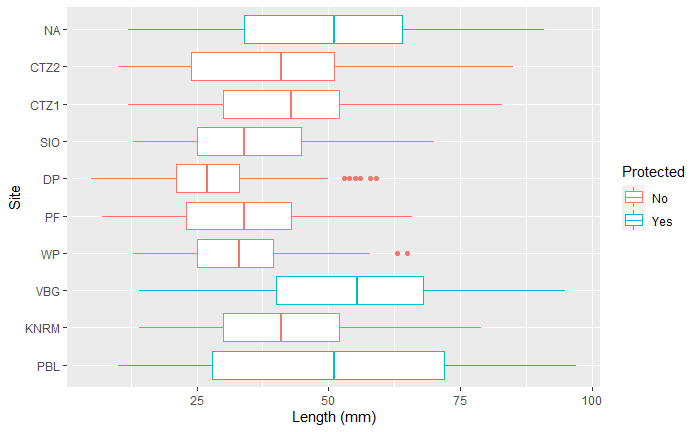

The DP and WP sites have some outliers longer than the rest of the data. For the most part, the protected sites tend to have larger Limpets.

#### Roseate Terns

## Reading and Naming data terns

```r
terns <- read_tsv(here("data", "roseate_terns.txt"))
```

## Viewing data

| year | AR | AL | AC | BR | BL | BC | JR | JL | JC |
| --- | --- | --- | --- | --- | --- | --- | --- | --- | --- |
| 1992 | 378 | 76 | 29 | 378 | NA | 29 | 651 | NA | 35 |
| 1993 | 427 | 76 | 28 | 427 | 76 | 28 | 717 | 50 | 30 |
| 1994 | 394 | 140 | 35 | 394 | NA | 35 | 553 | NA | 35 |
| 1995 | 554 | 62 | 36 | 554 | 62 | 36 | 697 | 96 | 36 |
| 1996 | 563 | 124 | 24 | 563 | 124 | 24 | 770 | 106 | 24 |
| 1997 | 602 | 48 | 25 | 34 | 48 | 25 | 35 | 52 | 17 |
| 1998 | 578 | 80 | 29 | 79 | 9 | 29 | 69 | 13 | 33 |
| 1999 | 611 | 116 | 34 | 125 | 14 | 34 | 161 | 20 | 33 |
| 2000 | 618 | NA | 34 | 174 | NA | 34 | 265 | NA | 33 |
| 2001 | 605 | 46 | 42 | 80 | 46 | 42 | 118 | 0 | 55 |

[output cut: 15 more lines]

## Tidying data

```r
terns <- terns %>%
  pivot_longer(c(AR:JC), names_to="Site",values_to="Population")
```

[output not shown]

## Confirming tidying

| year | Site | Population |
| --- | --- | --- |
| 1992 | AR | 378 |
| 1992 | AL | 76 |
| 1992 | AC | 29 |
| 1992 | BR | 378 |
| 1992 | BL | NA |
| 1992 | BC | 29 |
| 1992 | JR | 651 |
| 1992 | JL | NA |
| 1992 | JC | 35 |
| 1993 | AR | 427 |

[output cut: 215 more lines]

## Filtering out NAs

```r
terns_complete_data <- filter(drop_na(terns))
```

## Confirming NAs removed

| year | Site | Population |
| --- | --- | --- |
| 1992 | AR | 378 |
| 1992 | AL | 76 |
| 1992 | AC | 29 |
| 1992 | BR | 378 |
| 1992 | BC | 29 |
| 1992 | JR | 651 |
| 1992 | JC | 35 |
| 1993 | AR | 427 |
| 1993 | AL | 76 |
| 1993 | AC | 28 |

[output cut: 204 more lines]

## Line graph of Population vs. year of each site

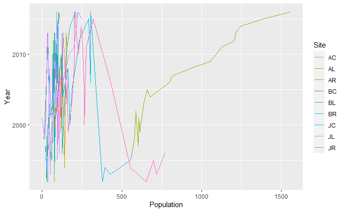

AC, AR, BC, JC obviously increase in population over time.

BR, JR had obvious decreases in population over time.

The line breaks come from haveing no data from that site in that year.

#### Blacklip Abalone

## Chunk 1: Reading abalone data, removing first column, and making a boxplot of each type

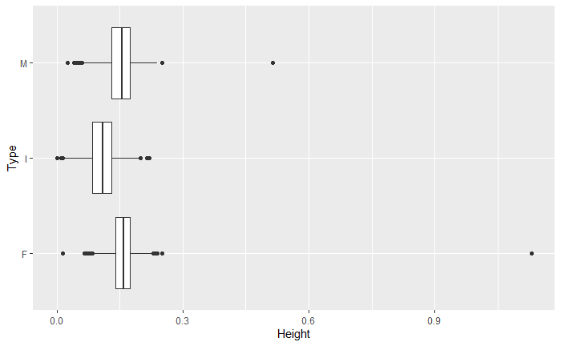

## Chunk 2: Scatterplot of Height vs. Rings to determine if outliers are old

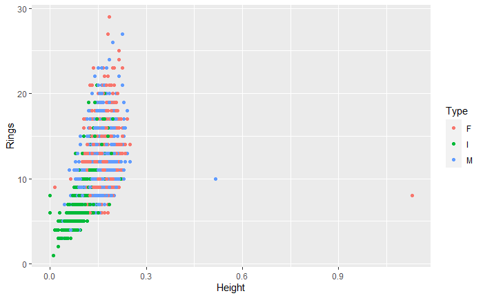

No, it does not appear that the two outliers are exceptionally old, they both have <= 10 rings.

## Chunk 3: Filtering out the two outliers as coding errors, Ordering Type from I to M to F. Replotting to see trends.

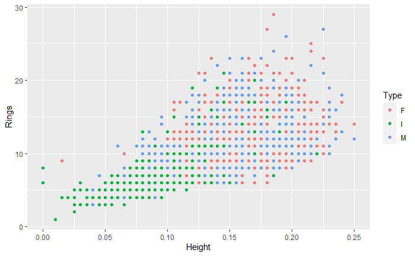

For the most part, the Immature ones are the shortest and have fewer rings; they are juveniles. The males and females seem to be evenly dispersed with no real trends on height or rings bases on sex.

#### Chunk 4: Assigned NA to Height = 0 and plotting results

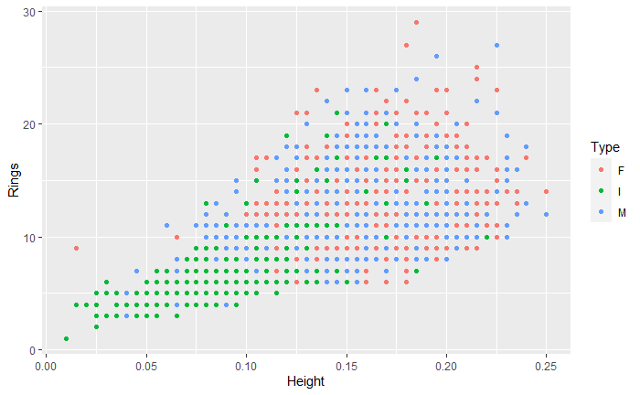

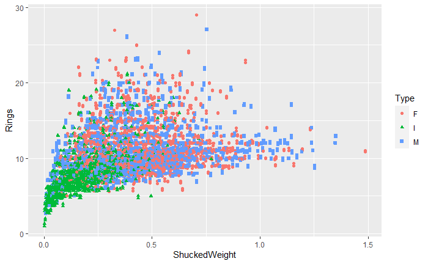

#### Darters

## Importing Darters data. Setting Columns, naming coloumns, and setting orders

```r
darter_data <- read_fwf(here("data", "darter.txt"), fwf_widths(c(3, 11, 1, 1, 1, 3, 4, 4, 4, 3, 3, 2, 2)), comment = "#")
```

## Filtering out zonale and tetrazonum spcecies, removing MinSub and Min Type columns, renaming the MajSub Proportion and Major Type columns, aranging by Sample

```r
darter_plots <- darter_data %>% filter(Species != "zonale" & Species != "tetrazonum") %>%
  select(!"MinSub Proportion" & ! "Minor Type") %>%
  rename("major_substarte" = "MajSub Proportion", "major_type" = "Major Type") %>%
  arrange("Sample")
```

##Plot of Legth vs. Depth of each riffle for each species

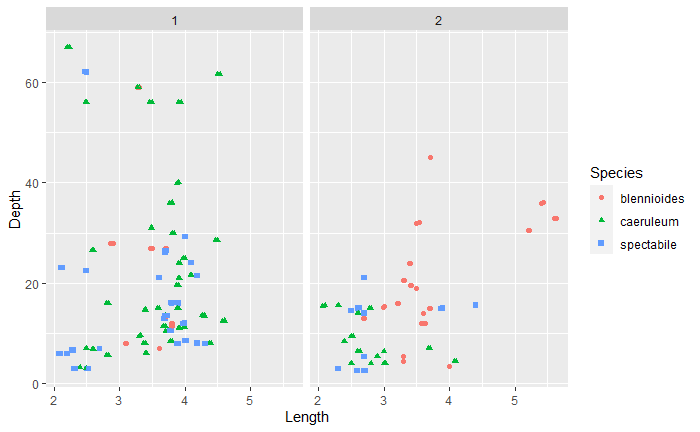

## Box plot of Length of each riffle for each species.

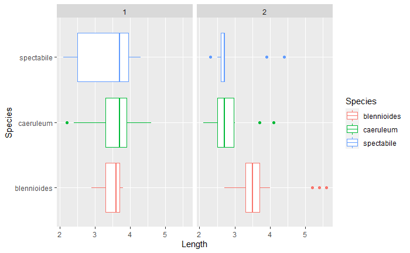

Riffle 1 shows one outlier, Riffle 2 has the most.

## Box plot of Length of darters for each major type by Species and Riffle

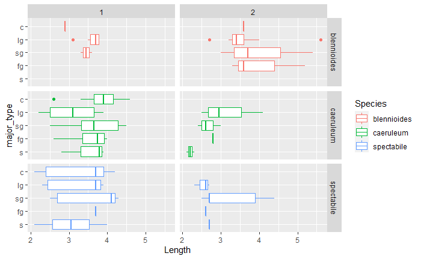

## Same plot as above just with facet_grid variables switched.

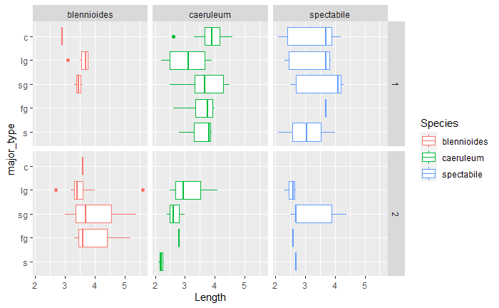

The axes switch between (Species ~ Riffle) and (Riffle ~ Species)